# EPID600 FINAL PROJECT, SEDENTARY BEHAVIOR AND 30-YEAR FULL CVD RISK

Alexandra L. Hanlon, PhD

#### Importing and wrangling with data

```r
library(dplyr)
```

```r
library(ggplot2)
temp1 <- read.csv(file = "Q:/Alex Hanlon/sedentary_data_for_R.csv", header = TRUE)
temp2 <- dplyr::rename (temp1, TOTAL_PHYS_ACTIVITY_N =  TOTAL_PHYS, BLOOD_PRESSURE_N = SYS_BP_AUTO,
          FRUITVEG_N = FRUIT_VEG, BMI_N = BMI, BODY_FAT_N = BODY_FAT
                )

temp3 <- dplyr::mutate(temp2, GENDER = factor(SEX, labels=c("Female", "Male")),
           RACE = factor(RACE_NEW, labels=c("Mixed/Other", "Asian","Black","White")),
           COLLEGE_C = factor(COLLEGE,labels = c("No", "Yes")),
           EMPLOYMENT_C = factor(EMPLOYMENT, labels = c("Employed",
                                                        "Unemployed",
                                                        "Retired")),
           SHIFT_WORK_C = factor(SHIFT_WORK, labels = c("No", "Yes")),
           RESIDENCE_C = factor(RESIDENCE, labels = c("Urban", "Rural")),
           DEPRESSION_C = factor(MH_STATUS, labels = c("No", "Yes")),
           SEASON_ASSESS_C = factor(SEASON_ASSESS, labels = c("Fall",
                                                    "Winter",
                                                    "Spring",
                                                    "Summer")),
           CHRONO_C = factor(CHRONO_4_CAT, labels = c("Definitely morning",
                                                    "More morning than evening",
                                                    "More evening than morning",
                                                    "Definitely evening")),
           SLEEP_C = factor(SLEEP, labels = c("Short", "Long", "Adequate")),
           DIABETES_C = factor(DIABETES, labels = c("No", "Yes")),
           SMOKE_C = factor(SMOKE, labels = c("No", "Yes")),
           HYPERTENSION_MEDS_C = factor(BP_MEDS_ALL, labels = c("No", "Yes")),
           PHYSICAL_ACTIVITY_C = factor(PHYSACT_REC, labels = c("No", "Yes")),
           FRUITVEG_RECOMMEND_MET_C = factor(FRUITVEG_REC, labels = c("No", "Yes")),
           ALCOHOL_INTAKE_C = factor(ALCOHOL_INTAKE, labels = c("Daily or almost daily",
                                                    "Three or four times a week",
                                                    "Once or twice a week",
                                                    "One to three times a month",
                                                    "Special occasions only",
                                                    "Never")),
           CVD_RISK_C = factor(FULL_CVD_RISK >= 0.4, labels = c("Low", "High"))
           )

## Keep only the variables that are needed for the analysis
temp4 <- dplyr::select(temp3, TV_HRS, COMP_HRS, DRIVE_HRS, AGE, GENDER, CHRONO_C,SLEEP_C,DIABETES_C,SMOKE_C,HYPERTENSION_MEDS_C,PHYSICAL_ACTIVITY_C,FRUITVEG_RECOMMEND_MET_C,
                       ALCOHOL_INTAKE_C,CVD_RISK_C,BLOOD_PRESSURE_N, BMI_N , BODY_FAT_N,TOTAL_PHYS_ACTIVITY_N,
          FRUITVEG_N)

## Keep only the observations with nonomissing values for all variables of interest
data <- temp4[complete.cases(temp4),]
str(data)
```

```
## 'data.frame':    320889 obs. of  19 variables:
##  $ TV_HRS                  : num  2 3 2 3 0 1 6 3 4 3 ...
##  $ COMP_HRS                : num  0.5 1 0 0.5 0.5 2 2 0.5 0.5 0 ...
##  $ DRIVE_HRS               : int  2 1 1 2 1 0 0 0 0 2 ...
##  $ AGE                     : int  42 45 46 62 53 66 64 59 56 57 ...
##  $ GENDER                  : Factor w/ 2 levels "Female","Male": 1 1 1 1 1 2 2 2 2 2 ...
##  $ CHRONO_C                : Factor w/ 4 levels "Definitely morning",..: 3 3 2 2 4 3 4 3 1 1 ...
##  $ SLEEP_C                 : Factor w/ 3 levels "Short","Long",..: 3 1 1 3 1 3 3 3 3 1 ...
##  $ DIABETES_C              : Factor w/ 2 levels "No","Yes": 1 1 1 1 1 1 1 1 1 1 ...
##  $ SMOKE_C                 : Factor w/ 2 levels "No","Yes": 1 1 1 1 1 1 1 2 1 1 ...
##  $ HYPERTENSION_MEDS_C     : Factor w/ 2 levels "No","Yes": 1 2 1 2 1 2 1 1 2 1 ...
##  $ PHYSICAL_ACTIVITY_C     : Factor w/ 2 levels "No","Yes": 2 1 2 2 1 1 2 2 2 1 ...
##  $ FRUITVEG_RECOMMEND_MET_C: Factor w/ 2 levels "No","Yes": 1 1 1 2 1 1 1 1 1 1 ...
##  $ ALCOHOL_INTAKE_C        : Factor w/ 6 levels "Daily or almost daily",..: 3 2 1 3 2 2 3 1 2 1 ...
##  $ CVD_RISK_C              : Factor w/ 2 levels "Low","High": 1 2 1 2 1 2 2 2 2 2 ...
##  $ BLOOD_PRESSURE_N        : int  119 142 177 129 119 154 162 167 146 174 ...
##  $ BMI_N                   : num  26.4 41.1 23.9 25.1 27.9 ...
##  $ BODY_FAT_N              : num  36.8 43.5 31.8 37.2 36.9 19.7 20.9 25.6 24.6 30.8 ...
##  $ TOTAL_PHYS_ACTIVITY_N   : int  180 140 450 285 50 60 300 1440 300 120 ...
##  $ FRUITVEG_N              : num  1.33 3 1.83 5 4.33 ...
```

```r
write.csv(data, file = "data_for_Alex.csv")
```

#### Descriptive Statistics

1. Summary of CVD risk dummy

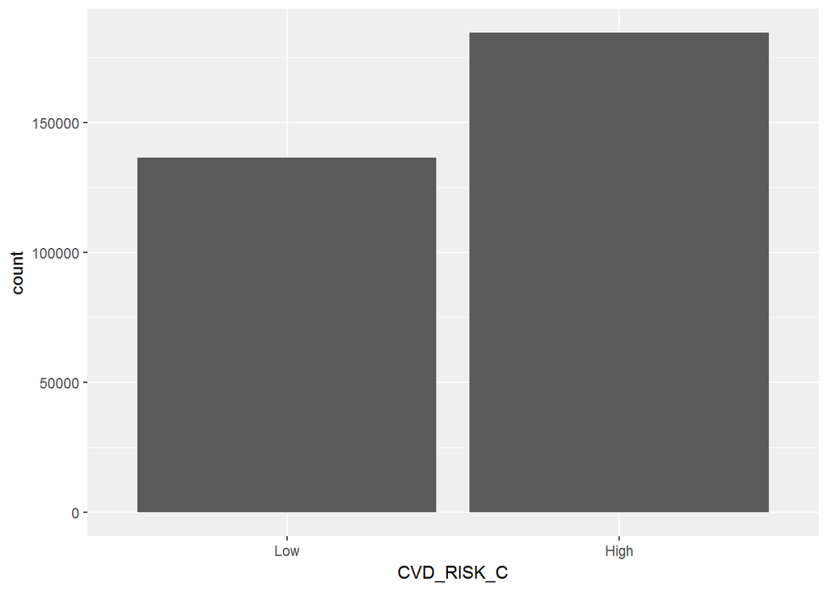

```r
ggplot(data=data, aes(x=CVD_RISK_C)) +
    geom_bar()
```

```r
summary(data$CVD_RISK_C)
```

```
##    Low   High
## 136369 184520
```

2. Summary of risk score components and compare them by CVD risk group

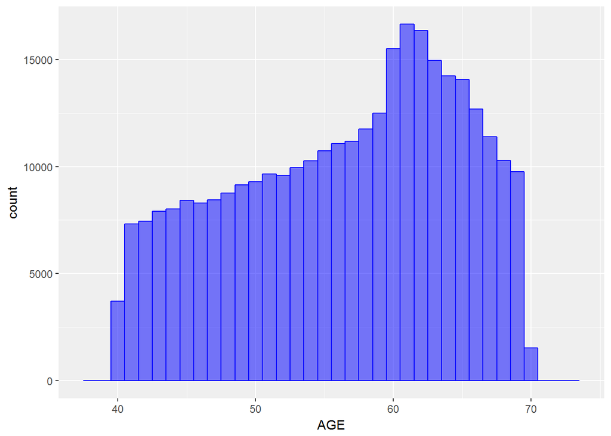

```r
#Age
qplot(AGE, data=data, geom="histogram", binwidth=1, col=I("blue"), fill=I("blue"), alpha=I(0.5))
```

```r
summary(data$AGE)
```

```
##    Min. 1st Qu.  Median    Mean 3rd Qu.    Max.
##   38.00   50.00   58.00   56.38   63.00   73.00
```

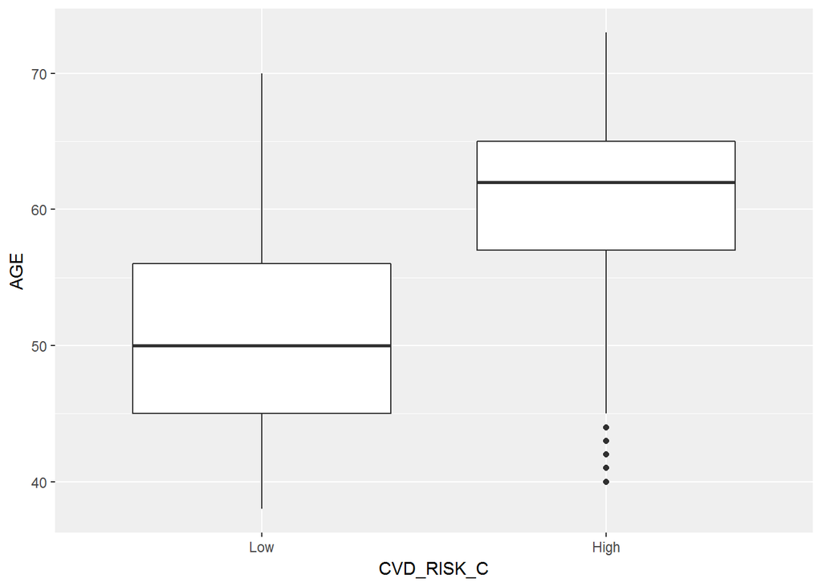

```r
ggplot(data = data, aes(CVD_RISK_C, AGE)) +
  geom_boxplot()
```

```r
t.test(AGE~CVD_RISK_C, data = data)
```

```
##
##  Welch Two Sample t-test
##
## data:  AGE by CVD_RISK_C
## t = -404.34, df = 269050, p-value < 2.2e-16
## alternative hypothesis: true difference in means is not equal to 0
## 95 percent confidence interval:
##  -9.731927 -9.638033
## sample estimates:
##  mean in group Low mean in group High
##           50.81551           60.50049
```

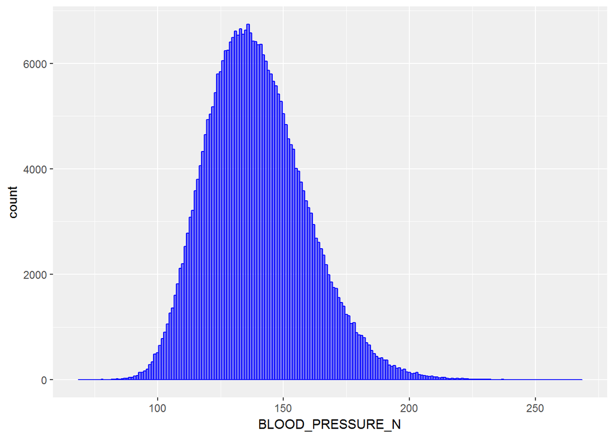

```r
#Blood pressure
qplot(BLOOD_PRESSURE_N, data=data, geom="histogram", binwidth=1, col=I("blue"), fill=I("blue"), alpha=I(0.5))
```

```r
summary(data$BLOOD_PRESSURE_N)
```

```
##    Min. 1st Qu.  Median    Mean 3rd Qu.    Max.
##    69.0   125.0   138.0   139.5   152.0   268.0
```

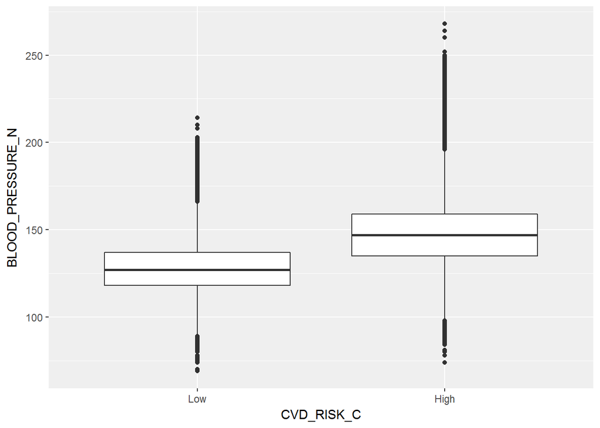

```r
ggplot(data = data, aes(CVD_RISK_C, BLOOD_PRESSURE_N)) +
  geom_boxplot()
```

```r
t.test(BLOOD_PRESSURE_N~CVD_RISK_C, data = data)
```

```
##
##  Welch Two Sample t-test
##
## data:  BLOOD_PRESSURE_N by CVD_RISK_C
## t = -347.19, df = 318870, p-value < 2.2e-16
## alternative hypothesis: true difference in means is not equal to 0
## 95 percent confidence interval:
##  -20.37618 -20.14741
## sample estimates:
##  mean in group Low mean in group High
##           127.8316           148.0934
```

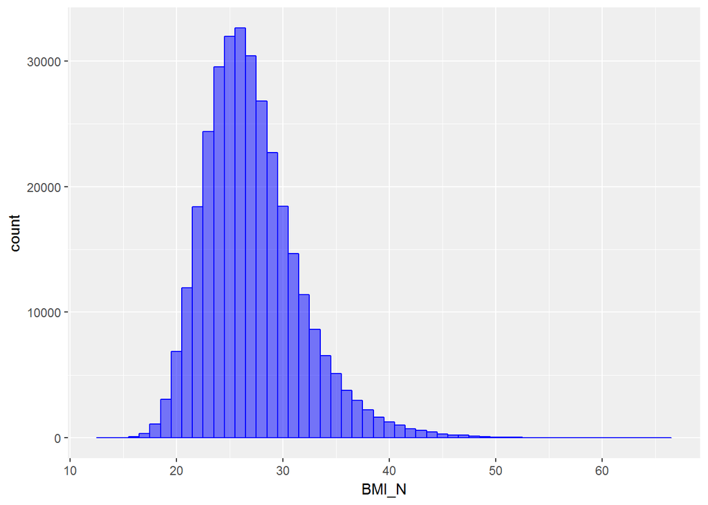

```r
#BMI
qplot(BMI_N, data=data, geom="histogram", binwidth=1, col=I("blue"), fill=I("blue"), alpha=I(0.5))
```

```r
summary(data$BMI_N)
```

```
##    Min. 1st Qu.  Median    Mean 3rd Qu.    Max.
##   12.81   23.99   26.50   27.13   29.52   66.14
```

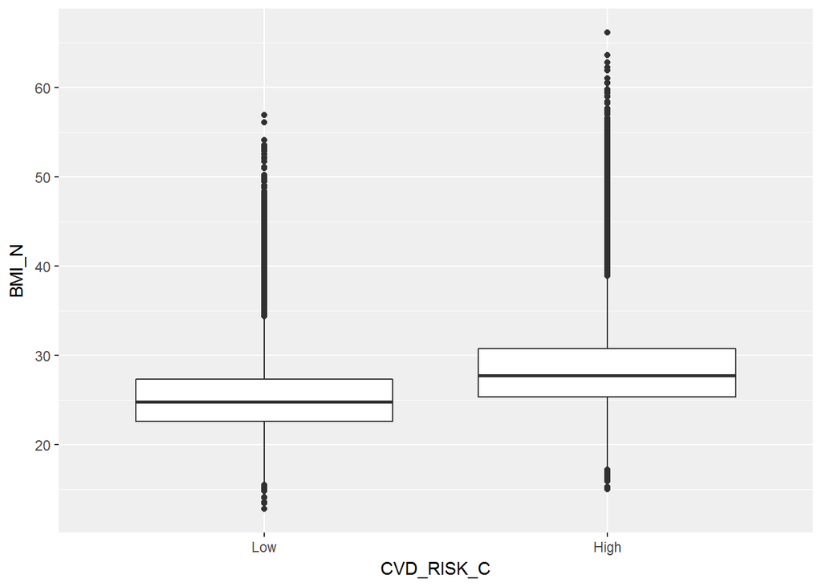

```r
ggplot(data = data, aes(CVD_RISK_C, BMI_N)) +
  geom_boxplot()
```

```r
t.test(BMI_N~CVD_RISK_C, data = data)
```

```
##
##  Welch Two Sample t-test
##
## data:  BMI_N by CVD_RISK_C
## t = -210.71, df = 313870, p-value < 2.2e-16
## alternative hypothesis: true difference in means is not equal to 0
## 95 percent confidence interval:
##  -3.169346 -3.110928
## sample estimates:
##  mean in group Low mean in group High
##           25.32106           28.46120
```

```r
#Gender

prop.table(table(data$GENDER))
```

```
##
##    Female      Male
## 0.5463447 0.4536553
```

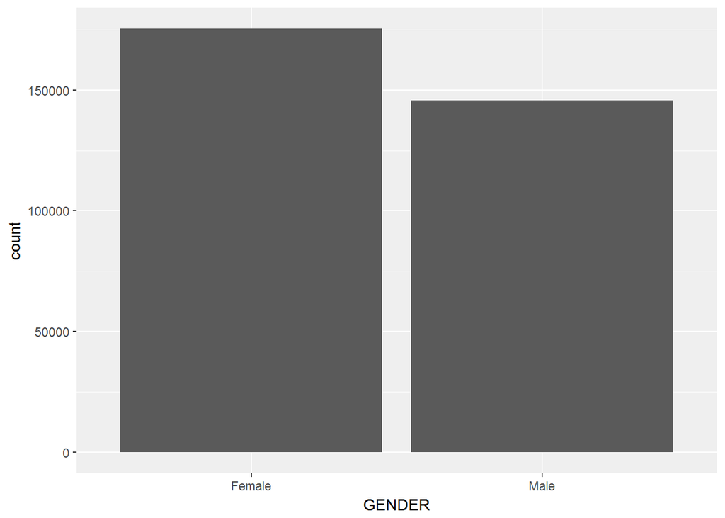

```r
ggplot(data=data, aes(x=GENDER)) +
    geom_bar()
```

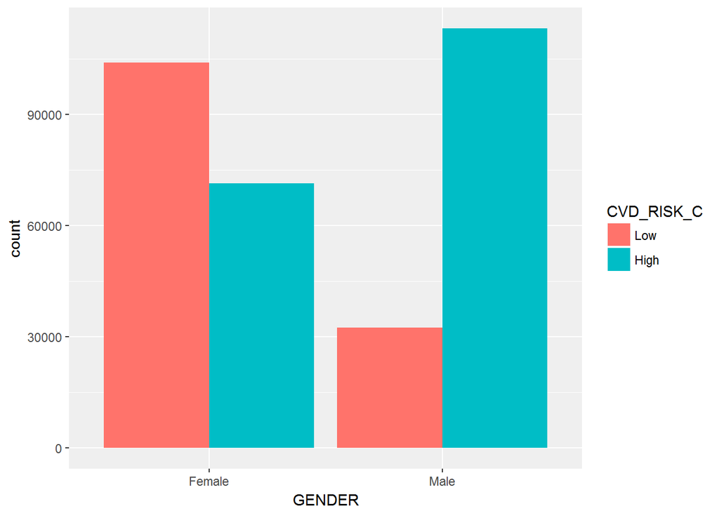

```r
ggplot(data = data, aes(fill = CVD_RISK_C, x = GENDER)) +
  geom_bar(position = "dodge")
```

```r
chisq.test(table(data$CVD_RISK_C, data$GENDER))
```

```
##
##  Pearson's Chi-squared test with Yates' continuity correction
##
## data:  table(data$CVD_RISK_C, data$GENDER)
## X-squared = 44679, df = 1, p-value < 2.2e-16
```

```r
#Smoking status

prop.table(table(data$SMOKE_C))
```

```
##
##         No        Yes
## 0.93655438 0.06344562
```

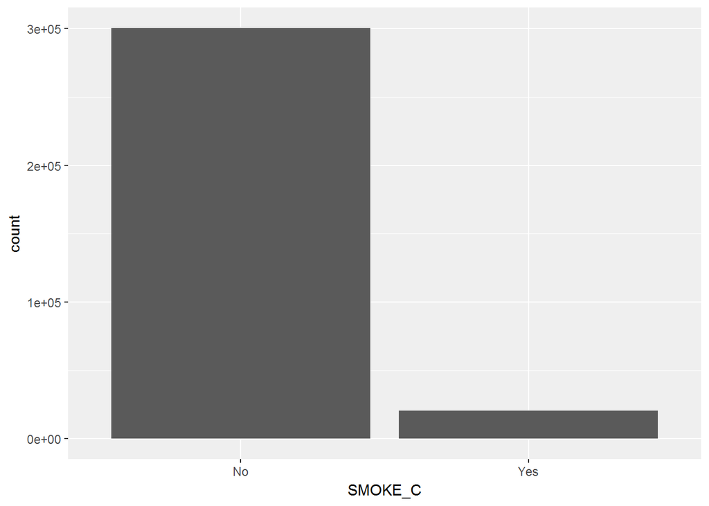

```r
ggplot(data=data, aes(x=SMOKE_C)) +
    geom_bar()
```

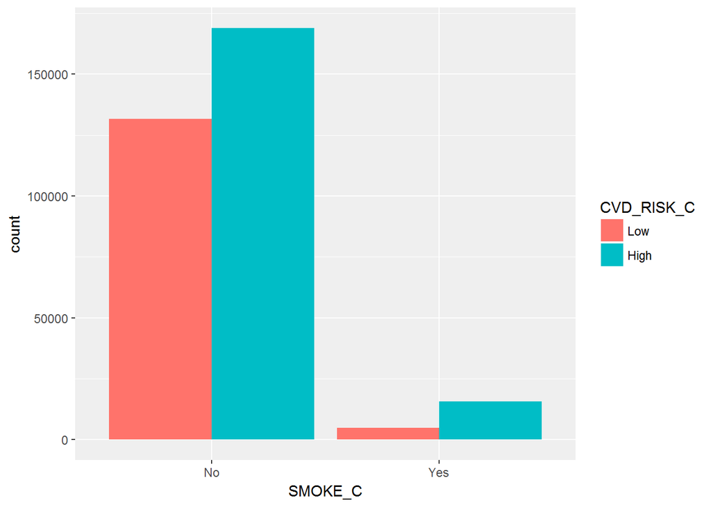

```r
ggplot(data = data, aes(fill = CVD_RISK_C, x = SMOKE_C)) +
  geom_bar(position = "dodge")
```

```r
chisq.test(table(data$CVD_RISK_C, data$SMOKE_C))
```

```
##
##  Pearson's Chi-squared test with Yates' continuity correction
##
## data:  table(data$CVD_RISK_C, data$SMOKE_C)
## X-squared = 3278.6, df = 1, p-value < 2.2e-16
```

```r
#Diabetes
prop.table(table(data$DIABETES_C))
```

```
##
##         No        Yes
## 0.95684801 0.04315199
```

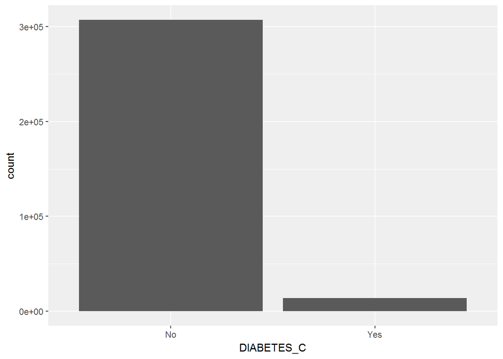

```r
ggplot(data=data, aes(x=DIABETES_C)) +
    geom_bar()
```

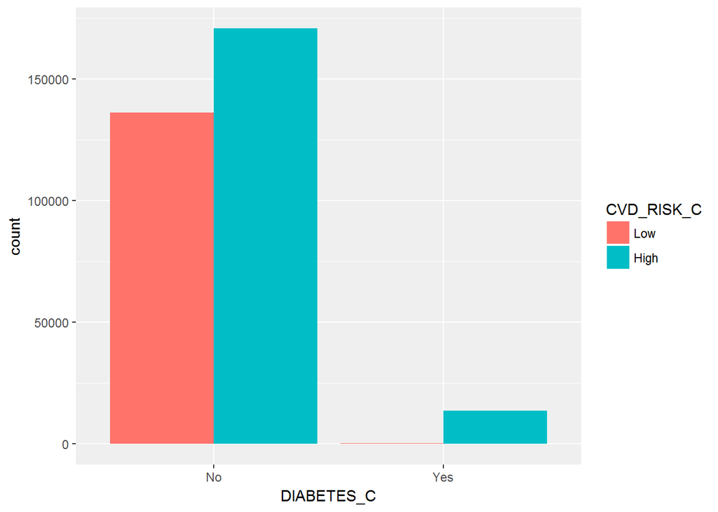

```r
ggplot(data = data, aes(fill = CVD_RISK_C, x = DIABETES_C)) +
  geom_bar(position = "dodge")
```

```r
chisq.test(table(data$CVD_RISK_C, data$DIABETES_C))
```

```
##
##  Pearson's Chi-squared test with Yates' continuity correction
##
## data:  table(data$CVD_RISK_C, data$DIABETES_C)
## X-squared = 9978.7, df = 1, p-value < 2.2e-16
```

```r
# Treatment of hypertensionn

prop.table(table(data$HYPERTENSION_MEDS_C))
```

```
##
##       No      Yes
## 0.807167 0.192833
```

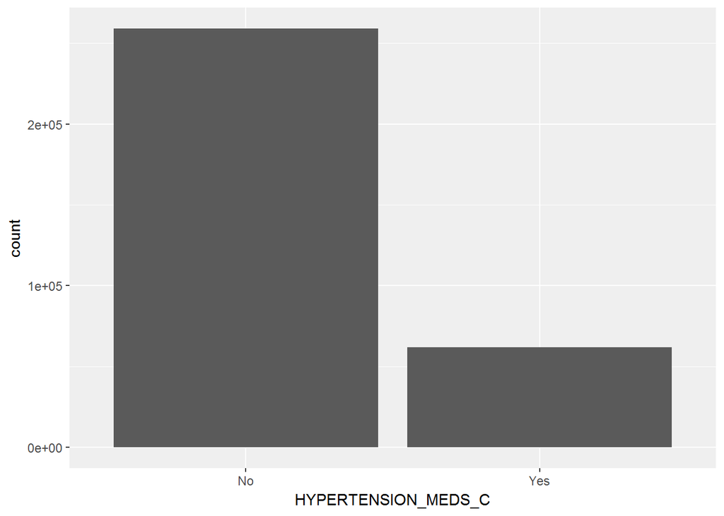

```r
ggplot(data=data, aes(x=HYPERTENSION_MEDS_C)) +
    geom_bar()
```

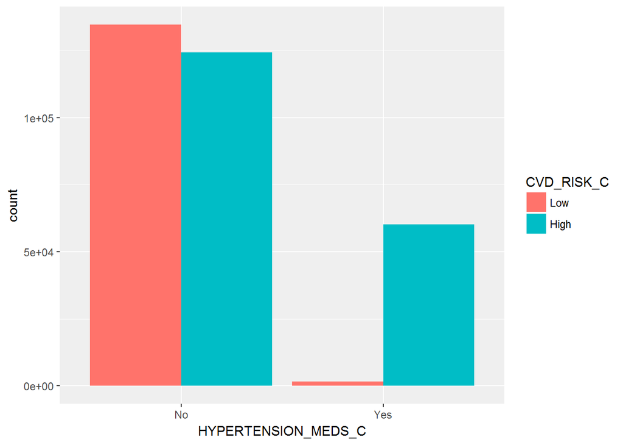

```r
ggplot(data = data, aes(fill = CVD_RISK_C, x = HYPERTENSION_MEDS_C)) +
  geom_bar(position = "dodge")
```

```r
chisq.test(table(data$CVD_RISK_C, data$HYPERTENSION_MEDS_C))
```

```
##
##  Pearson's Chi-squared test with Yates' continuity correction
##
## data:  table(data$CVD_RISK_C, data$HYPERTENSION_MEDS_C)
## X-squared = 49731, df = 1, p-value < 2.2e-16
```

3. Summary of sedentary behavior variables and compare them by CVD risk group

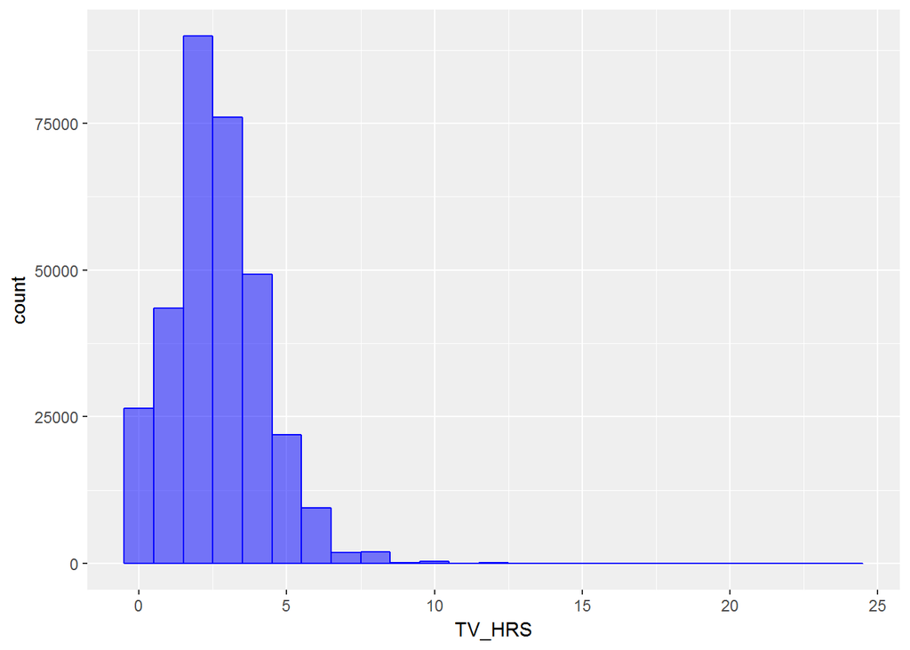

```r
#TV hours
qplot(TV_HRS, data=data, geom="histogram", binwidth=1, col=I("blue"), fill=I("blue"), alpha=I(0.5))
```

```r
summary(data$TV_HRS)
```

```
##    Min. 1st Qu.  Median    Mean 3rd Qu.    Max.
##   0.000   2.000   3.000   2.679   4.000  24.000
```

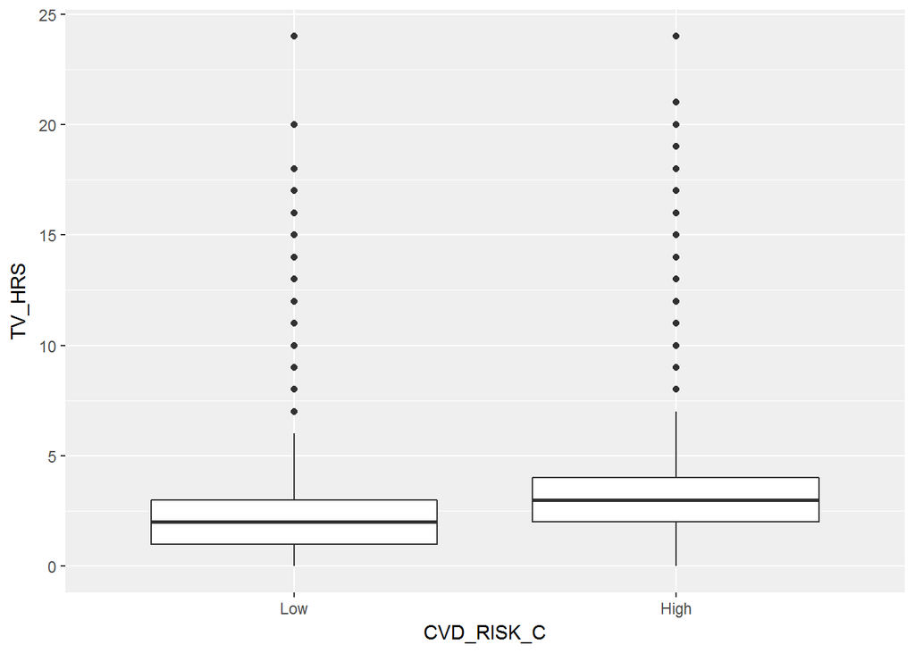

```r
ggplot(data = data, aes(CVD_RISK_C, TV_HRS)) +
  geom_boxplot()
```

```r
t.test(TV_HRS~CVD_RISK_C, data = data)
```

```
##
##  Welch Two Sample t-test
##
## data:  TV_HRS by CVD_RISK_C
## t = -125.18, df = 310910, p-value < 2.2e-16
## alternative hypothesis: true difference in means is not equal to 0
## 95 percent confidence interval:
##  -0.6809055 -0.6599125
## sample estimates:
##  mean in group Low mean in group High
##           2.293527           2.963936
```

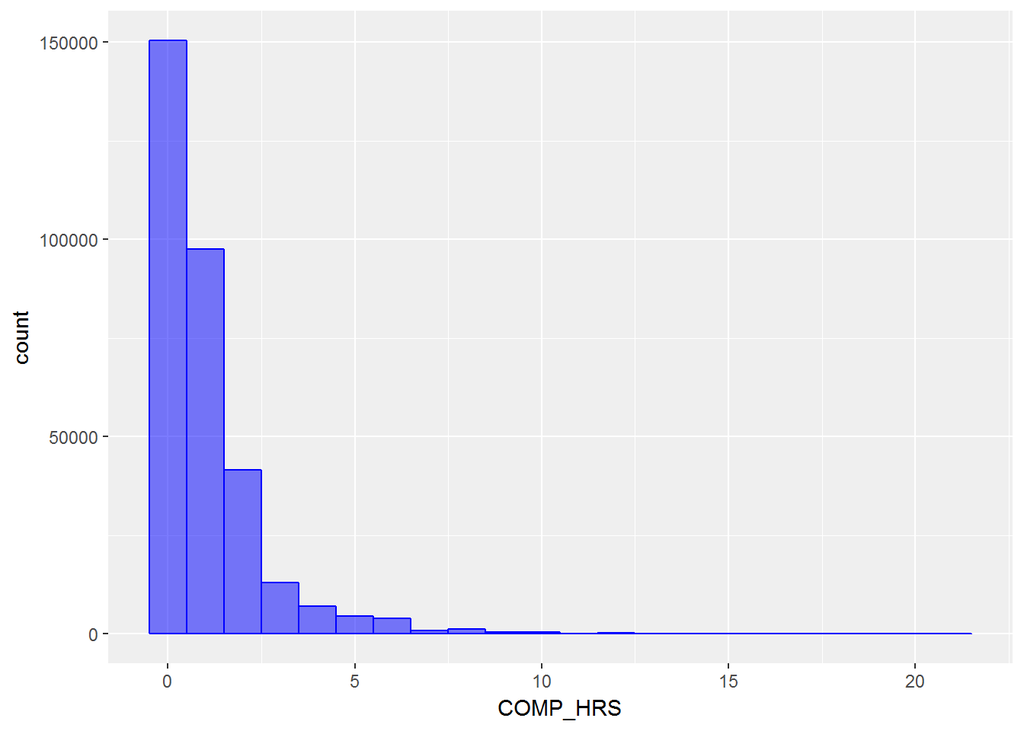

```r
#Computer hours

qplot(COMP_HRS, data=data, geom="histogram", binwidth=1, col=I("blue"), fill=I("blue"), alpha=I(0.5))
```

```r
summary(data$COMP_HRS)
```

```
##    Min. 1st Qu.  Median    Mean 3rd Qu.    Max.
##   0.000   0.000   1.000   1.102   1.000  21.000
```

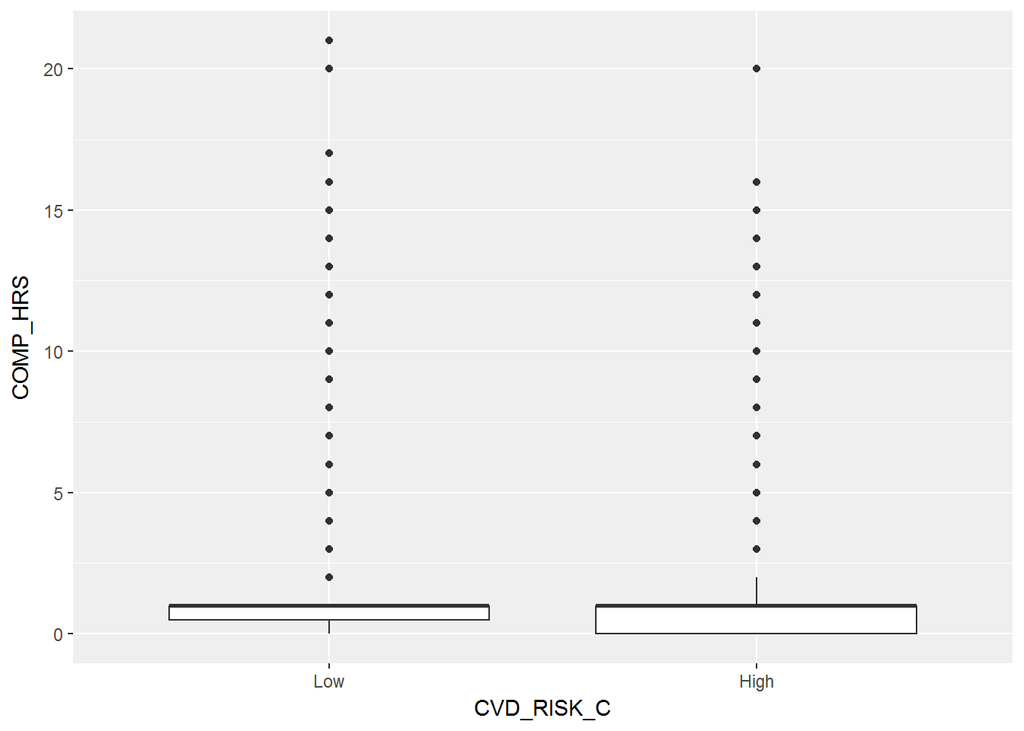

```r
ggplot(data = data, aes(CVD_RISK_C, COMP_HRS)) +
  geom_boxplot()
```

```r
t.test(COMP_HRS~CVD_RISK_C, data = data)
```

```
##
##  Welch Two Sample t-test
##
## data:  COMP_HRS by CVD_RISK_C
## t = -1.0809, df = 289090, p-value = 0.2798
## alternative hypothesis: true difference in means is not equal to 0
## 95 percent confidence interval:
##  -0.014882609  0.004302552
## sample estimates:
##  mean in group Low mean in group High
##           1.099227           1.104517
```

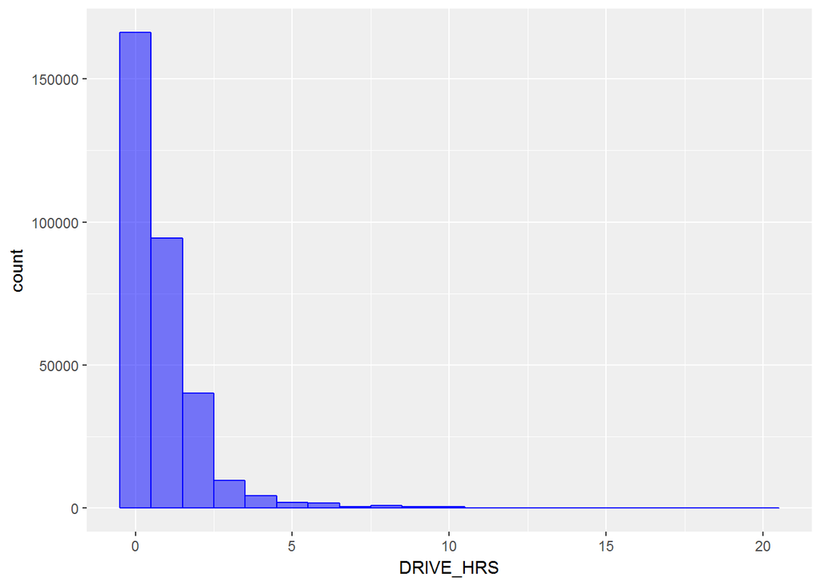

```r
#Drive hours

qplot(DRIVE_HRS, data=data, geom="histogram", binwidth=1, col=I("blue"), fill=I("blue"), alpha=I(0.5))
```

```r
summary(data$DRIVE_HRS)
```

```
##    Min. 1st Qu.  Median    Mean 3rd Qu.    Max.
##  0.0000  0.0000  0.0000  0.8202  1.0000 20.0000
```

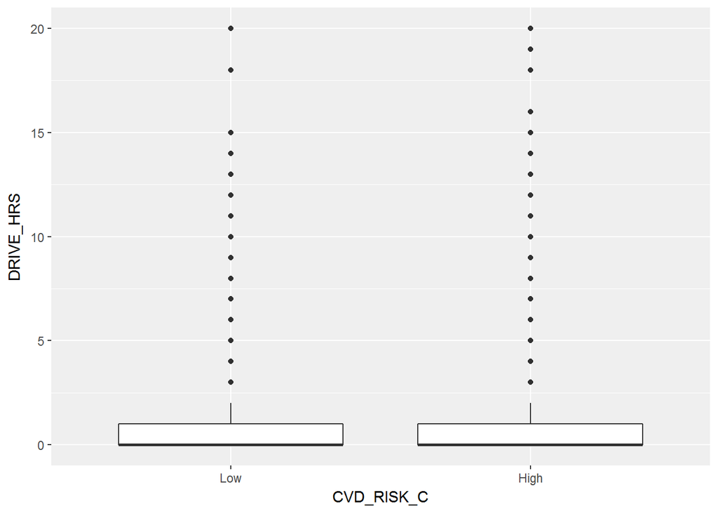

```r
ggplot(data = data, aes(CVD_RISK_C, DRIVE_HRS)) +
  geom_boxplot()
```

```r
t.test(DRIVE_HRS~CVD_RISK_C, data = data)
```

```
##
##  Welch Two Sample t-test
##
## data:  DRIVE_HRS by CVD_RISK_C
## t = -14.909, df = 314080, p-value < 2.2e-16
## alternative hypothesis: true difference in means is not equal to 0
## 95 percent confidence interval:
##  -0.07428218 -0.05702053
## sample estimates:
##  mean in group Low mean in group High
##          0.7824139          0.8480653
```

4. Summary of covariates and compare them by CVD risk group

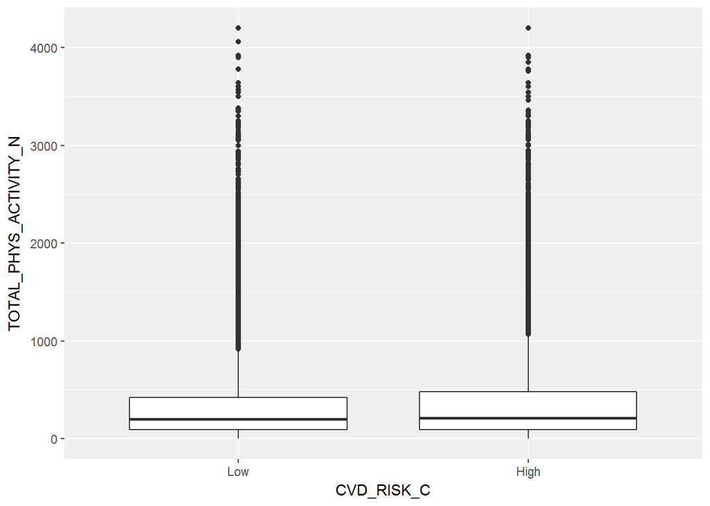

```r
#Total physical activity (continuous)

ggplot(data = data, aes(CVD_RISK_C, TOTAL_PHYS_ACTIVITY_N)) +
  geom_boxplot()
```

```r
t.test(TOTAL_PHYS_ACTIVITY_N~CVD_RISK_C, data = data)
```

```
##
##  Welch Two Sample t-test
##
## data:  TOTAL_PHYS_ACTIVITY_N by CVD_RISK_C
## t = -26.652, df = 309360, p-value < 2.2e-16
## alternative hypothesis: true difference in means is not equal to 0
## 95 percent confidence interval:
##  -44.73288 -38.60429
## sample estimates:
##  mean in group Low mean in group High
##           340.9115           382.5801
```

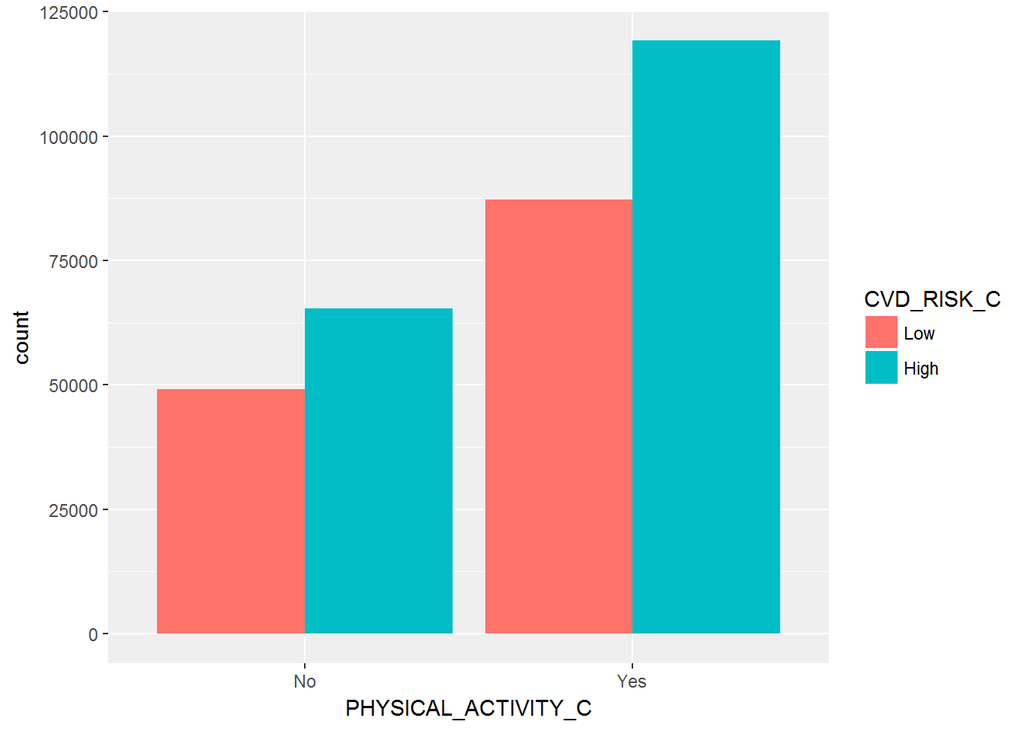

```r
#Total physical activity (categorical)

ggplot(data = data, aes(fill = CVD_RISK_C, x = PHYSICAL_ACTIVITY_C)) +
  geom_bar(position = "dodge")
```

```r
chisq.test(table(data$CVD_RISK_C, data$PHYSICAL_ACTIVITY_C))
```

```
##
##  Pearson's Chi-squared test with Yates' continuity correction
##
## data:  table(data$CVD_RISK_C, data$PHYSICAL_ACTIVITY_C)
## X-squared = 14.433, df = 1, p-value = 0.0001452
```

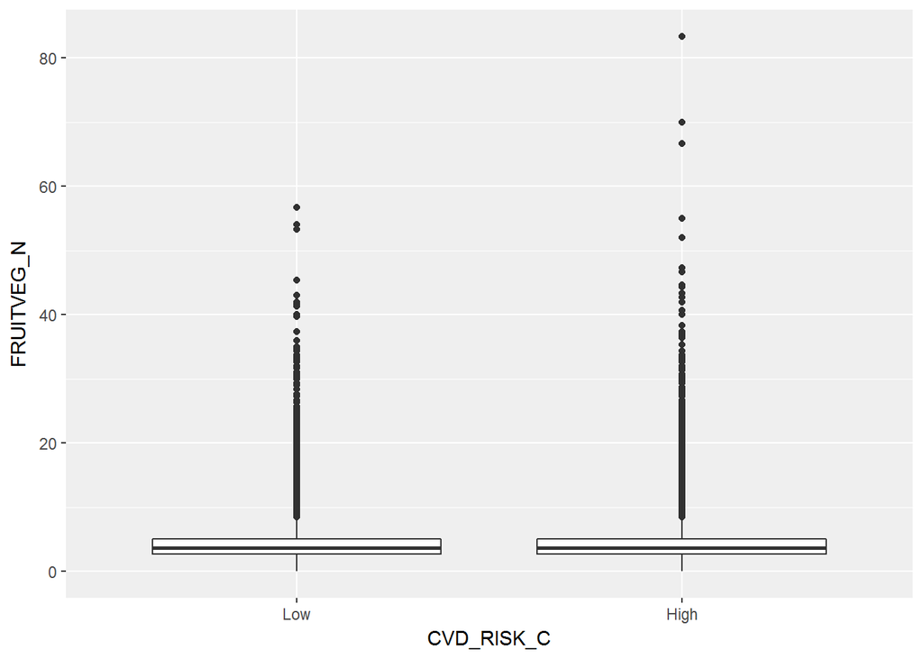

```r
#Fruit and Vegetable Intake (continuous)

ggplot(data = data, aes(CVD_RISK_C, FRUITVEG_N)) +
  geom_boxplot()
```

```r
t.test(FRUITVEG_N~CVD_RISK_C, data = data)
```

```
##
##  Welch Two Sample t-test
##
## data:  FRUITVEG_N by CVD_RISK_C
## t = 6.066, df = 296160, p-value = 1.313e-09
## alternative hypothesis: true difference in means is not equal to 0
## 95 percent confidence interval:
##  0.03163185 0.06183007
## sample estimates:
##  mean in group Low mean in group High
##           3.995410           3.948679
```

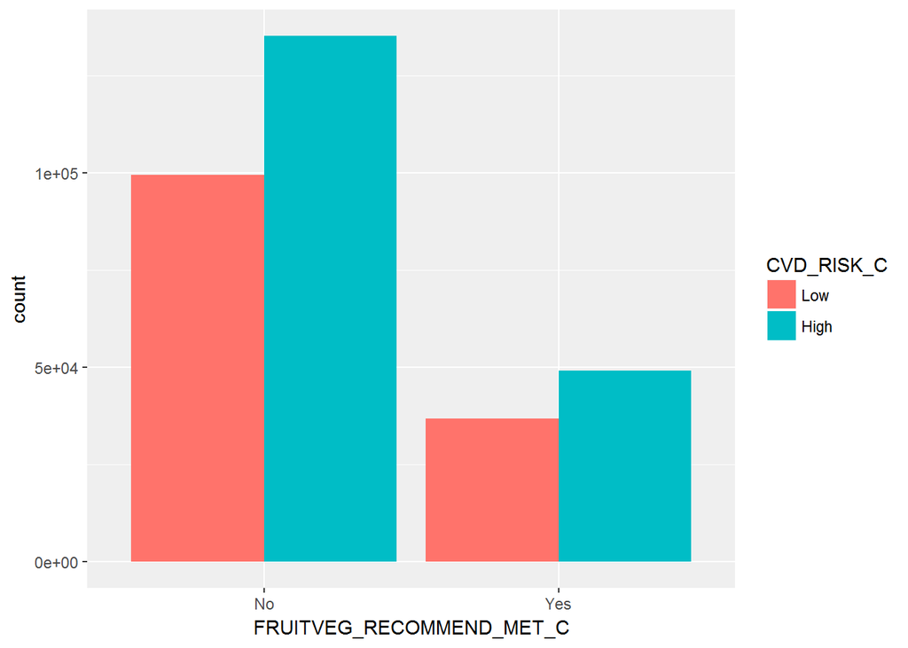

```r
#Fruit and Vegetable Intake (categorical)

ggplot(data = data, aes(fill = CVD_RISK_C, x = FRUITVEG_RECOMMEND_MET_C)) +
  geom_bar(position = "dodge")
```

```r
chisq.test(table(data$CVD_RISK_C, data$FRUITVEG_RECOMMEND_MET_C))
```

```
##
##  Pearson's Chi-squared test with Yates' continuity correction
##
## data:  table(data$CVD_RISK_C, data$FRUITVEG_RECOMMEND_MET_C)
## X-squared = 3.4914, df = 1, p-value = 0.06169
```

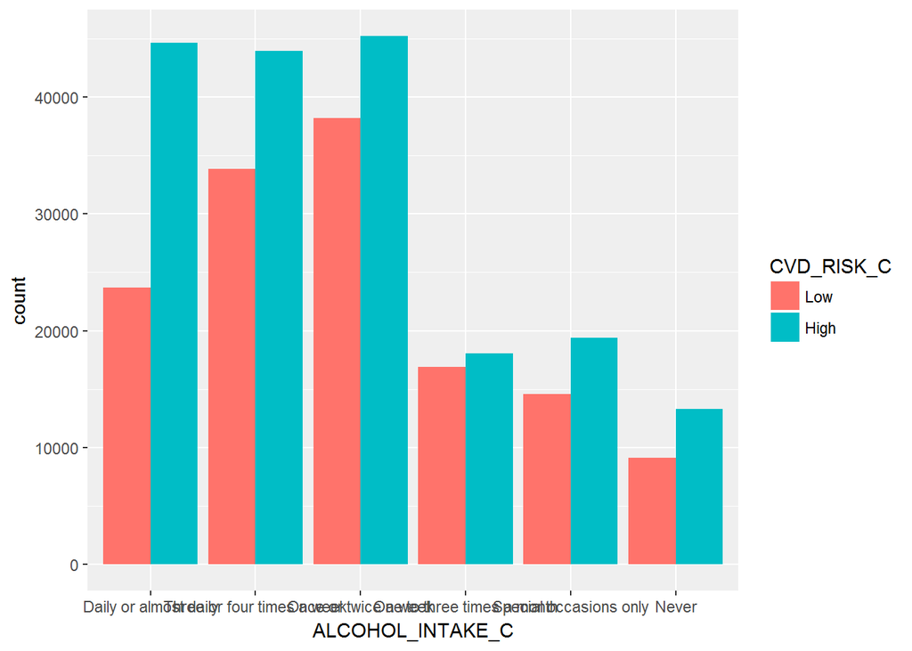

```r
#Alcohol intake (categorical)

ggplot(data = data, aes(fill = CVD_RISK_C, x = ALCOHOL_INTAKE_C)) +
  geom_bar(position = "dodge")
```

```r
chisq.test(table(data$CVD_RISK_C, data$ALCOHOL_INTAKE_C))
```

```
##
##  Pearson's Chi-squared test
##
## data:  table(data$CVD_RISK_C, data$ALCOHOL_INTAKE_C)
## X-squared = 2625.9, df = 5, p-value < 2.2e-16
```

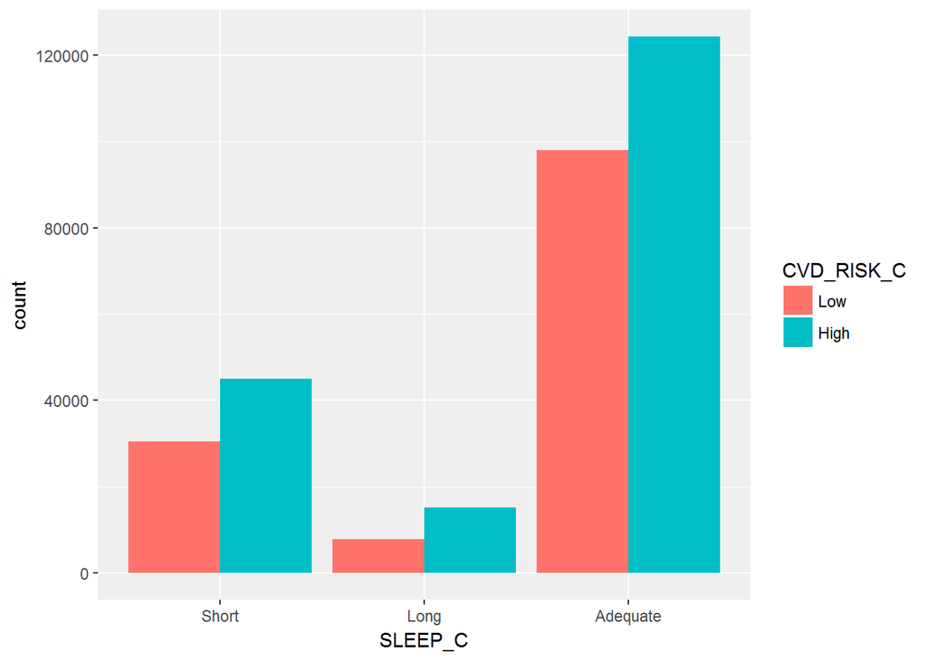

```r
#Sleep duration (categorical)

ggplot(data = data, aes(fill = CVD_RISK_C, x = SLEEP_C)) +
  geom_bar(position = "dodge")
```

```r
chisq.test(table(data$CVD_RISK_C, data$SLEEP_C))
```

```
##
##  Pearson's Chi-squared test
##
## data:  table(data$CVD_RISK_C, data$SLEEP_C)
## X-squared = 1040.1, df = 2, p-value < 2.2e-16
```

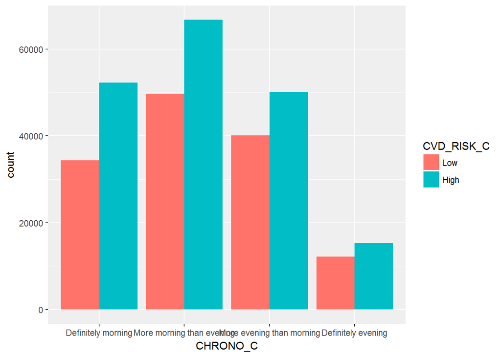

```r
#Sleep timing preference (categorical)

ggplot(data = data, aes(fill = CVD_RISK_C, x = CHRONO_C)) +
  geom_bar(position = "dodge")
```

```r
chisq.test(table(data$CVD_RISK_C, data$CHRONO_C))
```

```
##
##  Pearson's Chi-squared test
##
## data:  table(data$CVD_RISK_C, data$CHRONO_C)
## X-squared = 467.82, df = 3, p-value < 2.2e-16
```

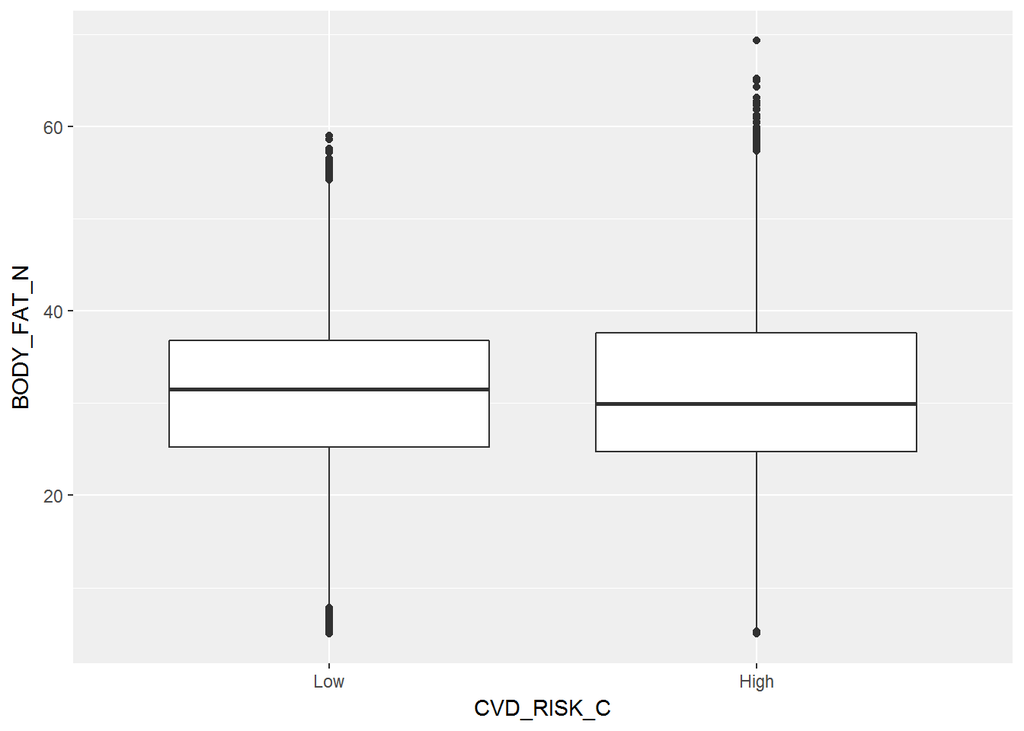

```r
#Body fat percentage (continuous)

ggplot(data = data, aes(CVD_RISK_C, BODY_FAT_N)) +
  geom_boxplot()
```

```r
t.test(BODY_FAT_N~CVD_RISK_C, data = data)
```

```
##
##  Welch Two Sample t-test
##
## data:  BODY_FAT_N by CVD_RISK_C
## t = -3.7138, df = 303580, p-value = 0.0002042
## alternative hypothesis: true difference in means is not equal to 0
## 95 percent confidence interval:
##  -0.16856651 -0.05210486
## sample estimates:
##  mean in group Low mean in group High
##           30.94533           31.05567
```

4. Decision tree

```r
library(rpart)
library(partykit)
```

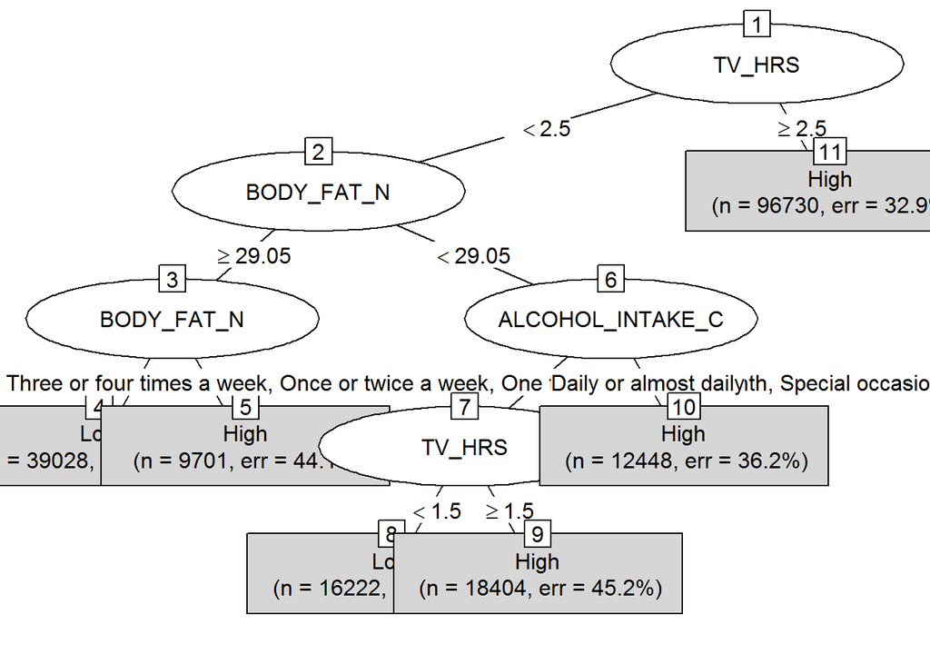

```r
library(rpart.plot)
library(caret)
set.seed(101)
train <- sample(1:nrow(data), nrow(data)*0.6)
test <- data[-train, "CVD_RISK_C"]
tree_cvd <- rpart(CVD_RISK_C~TV_HRS+COMP_HRS+DRIVE_HRS+
                    PHYSICAL_ACTIVITY_C+FRUITVEG_RECOMMEND_MET_C+
                    ALCOHOL_INTAKE_C+SLEEP_C+
                    CHRONO_C+BODY_FAT_N,  method="class", data=data, subset=train)
plot(as.party(tree_cvd), type="simple")
```

```r
#plot(as.party(tree1), type="extended")
summary(tree_cvd)
```

```
## Call:
## rpart(formula = CVD_RISK_C ~ TV_HRS + COMP_HRS + DRIVE_HRS +
##     PHYSICAL_ACTIVITY_C + FRUITVEG_RECOMMEND_MET_C + ALCOHOL_INTAKE_C +
##     SLEEP_C + CHRONO_C + BODY_FAT_N, data = data, subset = train,
##     method = "class")
##   n= 192533
##
##           CP nsplit rel error    xerror        xstd
## 1 0.04991992      0 1.0000000 1.0000000 0.002651861
## 2 0.03880623      1 0.9500801 0.9500801 0.002632043
## 3 0.01397464      2 0.9112739 0.9123498 0.002613680
## 4 0.01237300      3 0.8972992 0.8929589 0.002603088
## 5 0.01000000      5 0.8725532 0.8733724 0.002591580
##
## Variable importance
##                   TV_HRS               BODY_FAT_N         ALCOHOL_INTAKE_C
##                       58                       21                       10
##                 COMP_HRS                  SLEEP_C FRUITVEG_RECOMMEND_MET_C
##                        6                        3                        1
##
## Node number 1: 192533 observations,    complexity param=0.04991992
##   predicted class=High  expected loss=0.4248155  P(node) =1
##     class counts: 81791 110742
##    probabilities: 0.425 0.575
##   left son=2 (95803 obs) right son=3 (96730 obs)
##   Primary splits:
##       TV_HRS           < 2.5   to the left,  improve=3551.0150, (0 missing)
##       BODY_FAT_N       < 43.55 to the left,  improve= 688.8322, (0 missing)
##       COMP_HRS         < 0.25  to the right, improve= 686.8549, (0 missing)
##       ALCOHOL_INTAKE_C splits as  RLLLLL,    improve= 635.2381, (0 missing)
##       SLEEP_C          splits as  RRL,       improve= 241.3115, (0 missing)
##   Surrogate splits:
##       BODY_FAT_N               < 28.25 to the left,  agree=0.559, adj=0.113, (0 split)
##       COMP_HRS                 < 0.25  to the right, agree=0.557, adj=0.109, (0 split)
##       ALCOHOL_INTAKE_C         splits as  LLRRRR,    agree=0.530, adj=0.055, (0 split)
##       SLEEP_C                  splits as  RRL,       agree=0.526, adj=0.046, (0 split)
##       FRUITVEG_RECOMMEND_MET_C splits as  RL,        agree=0.515, adj=0.025, (0 split)
##
## Node number 2: 95803 observations,    complexity param=0.03880623
##   predicted class=Low   expected loss=0.4786906  P(node) =0.4975926
```

[output cut: 74 more lines]

```
##
## Node number 11: 12448 observations
##   predicted class=High  expected loss=0.3623072  P(node) =0.06465385
##     class counts:  4510  7938
##    probabilities: 0.362 0.638
##
## Node number 20: 16222 observations
##   predicted class=Low   expected loss=0.4376156  P(node) =0.08425569
##     class counts:  9123  7099
##    probabilities: 0.562 0.438
##
## Node number 21: 18404 observations
##   predicted class=High  expected loss=0.4519126  P(node) =0.09558881
##     class counts:  8317 10087
##    probabilities: 0.452 0.548
```

```r
yhat <- predict(tree_cvd, data[-train,], type="class")
nonmissing <- !is.na(test)
conf <- table(yhat[nonmissing], test[nonmissing])

f.conf <- confusionMatrix(conf)
print(f.conf)
```

```
## Confusion Matrix and Statistics
##
##
##          Low  High
##   Low  21847 14788
##   High 32731 58990
##
##                Accuracy : 0.6298
##                  95% CI : (0.6271, 0.6324)
##     No Information Rate : 0.5748
##     P-Value [Acc > NIR] : < 2.2e-16
##
##                   Kappa : 0.2088
##  Mcnemar's Test P-Value : < 2.2e-16
##
##             Sensitivity : 0.4003
##             Specificity : 0.7996
##          Pos Pred Value : 0.5963
##          Neg Pred Value : 0.6431
##              Prevalence : 0.4252
##          Detection Rate : 0.1702
##    Detection Prevalence : 0.2854
##       Balanced Accuracy : 0.5999
##
##        'Positive' Class : Low
##
```

5. Logistic regression and random forest modeling
   - Distriution of subjects by CVD risk (low/moderate vs high)

```r
data2 <- dplyr::select(data, CVD_RISK_C,
                       TV_HRS,COMP_HRS,DRIVE_HRS,
                       PHYSICAL_ACTIVITY_C,FRUITVEG_RECOMMEND_MET_C,
                       ALCOHOL_INTAKE_C,SLEEP_C,CHRONO_C,BODY_FAT_N)
str(data2)
```

```
## 'data.frame':    320889 obs. of  10 variables:
##  $ CVD_RISK_C              : Factor w/ 2 levels "Low","High": 1 2 1 2 1 2 2 2 2 2 ...
##  $ TV_HRS                  : num  2 3 2 3 0 1 6 3 4 3 ...
##  $ COMP_HRS                : num  0.5 1 0 0.5 0.5 2 2 0.5 0.5 0 ...
##  $ DRIVE_HRS               : int  2 1 1 2 1 0 0 0 0 2 ...
##  $ PHYSICAL_ACTIVITY_C     : Factor w/ 2 levels "No","Yes": 2 1 2 2 1 1 2 2 2 1 ...
##  $ FRUITVEG_RECOMMEND_MET_C: Factor w/ 2 levels "No","Yes": 1 1 1 2 1 1 1 1 1 1 ...
##  $ ALCOHOL_INTAKE_C        : Factor w/ 6 levels "Daily or almost daily",..: 3 2 1 3 2 2 3 1 2 1 ...
##  $ SLEEP_C                 : Factor w/ 3 levels "Short","Long",..: 3 1 1 3 1 3 3 3 3 1 ...
##  $ CHRONO_C                : Factor w/ 4 levels "Definitely morning",..: 3 3 2 2 4 3 4 3 1 1 ...
##  $ BODY_FAT_N              : num  36.8 43.5 31.8 37.2 36.9 19.7 20.9 25.6 24.6 30.8 ...
```

```r
table(data2$CVD_RISK_C)
```

```
##
##    Low   High
## 136369 184520
```

```
+ Univariate logistic regression models to examine variables  individually associated with CVD risk at a significance level <0.05.
```

```r
pvalues <- sapply( data2[,2:10], function(w) {
glm.fit <- glm(data$CVD_RISK_C ~ w, family=binomial)
summary(glm.fit)$coefficients[2,4]
})
pvalues[pvalues<0.05]
```

```
##              TV_HRS           DRIVE_HRS PHYSICAL_ACTIVITY_C
##        0.000000e+00        7.693816e-48        1.430884e-04
##    ALCOHOL_INTAKE_C             SLEEP_C            CHRONO_C
##       2.069953e-259        2.177752e-65        1.067954e-42
##          BODY_FAT_N
##        2.353951e-04
```

TV hours, driving hours, physical activity, alcohol intake, sleep duration, sleep timing preference, and body fat percentage are all statistically significant at p<0.05.

```
+ Generating a plot to visualize how TV hours (the values of the individual variable with lowest p-value) differ by risk group.
```

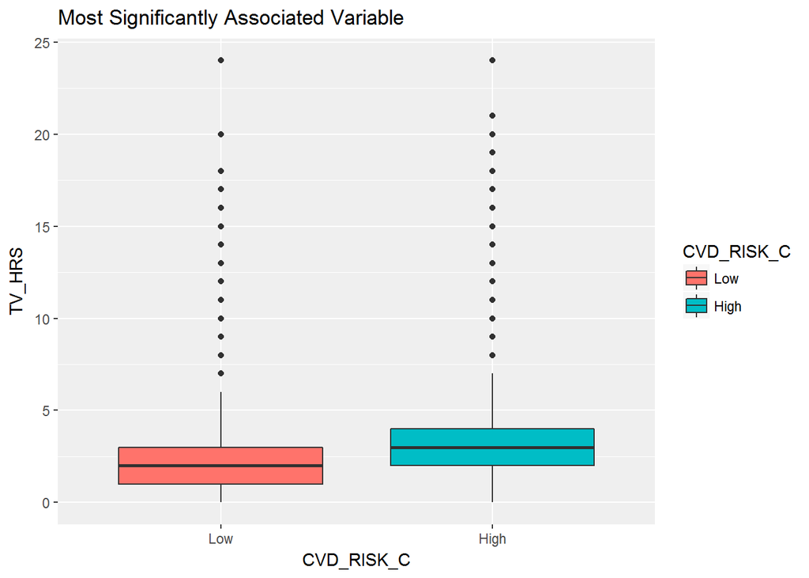

```r
ggplot(data2, aes(CVD_RISK_C, TV_HRS)) +
    geom_boxplot(aes(fill=CVD_RISK_C)) +
    labs(title="Most Significantly Associated Variable")
```

- Comparing the predictive accuracy of 1) Logistic regression and 2) Random forest multivariate models of CVD risk regressed on all independent variables simultaneously.

```r
#Logistic regression
full.glm <- glm(CVD_RISK_C~., data=data2, family=binomial(logit))
summary(full.glm)
```

```
##
## Call:
## glm(formula = CVD_RISK_C ~ ., family = binomial(logit), data = data2)
##
## Deviance Residuals:
##     Min       1Q   Median       3Q      Max
## -3.7774  -1.1863   0.7738   1.0435   1.6788
##
## Coefficients:
##                                              Estimate Std. Error z value
## (Intercept)                                 0.1490866  0.0204330   7.296
## TV_HRS                                      0.3206498  0.0026796 119.664
## COMP_HRS                                    0.0139787  0.0027480   5.087
## DRIVE_HRS                                   0.0452233  0.0029913  15.118
## PHYSICAL_ACTIVITY_CYes                      0.0262413  0.0077804   3.373
## FRUITVEG_RECOMMEND_MET_CYes                 0.0408245  0.0084172   4.850
## ALCOHOL_INTAKE_CThree or four times a week -0.3951068  0.0111028 -35.586
## ALCOHOL_INTAKE_COnce or twice a week       -0.5500675  0.0109922 -50.041
## ALCOHOL_INTAKE_COne to three times a month -0.6632070  0.0138919 -47.741
## ALCOHOL_INTAKE_CSpecial occasions only     -0.4736038  0.0142302 -33.282
## ALCOHOL_INTAKE_CNever                      -0.3637883  0.0164710 -22.087
## SLEEP_CLong                                 0.1948746  0.0163262  11.936
## SLEEP_CAdequate                            -0.1113054  0.0088725 -12.545
## CHRONO_CMore morning than evening          -0.1184000  0.0094479 -12.532
## CHRONO_CMore evening than morning          -0.2349081  0.0100274 -23.427
## CHRONO_CDefinitely evening                 -0.2337951  0.0145423 -16.077
## BODY_FAT_N                                 -0.0057998  0.0004597 -12.616
##                                            Pr(>|z|)
## (Intercept)                                2.96e-13 ***
## TV_HRS                                      < 2e-16 ***
## COMP_HRS                                   3.64e-07 ***
## DRIVE_HRS                                   < 2e-16 ***
## PHYSICAL_ACTIVITY_CYes                     0.000744 ***
## FRUITVEG_RECOMMEND_MET_CYes                1.23e-06 ***
## ALCOHOL_INTAKE_CThree or four times a week  < 2e-16 ***
## ALCOHOL_INTAKE_COnce or twice a week        < 2e-16 ***
## ALCOHOL_INTAKE_COne to three times a month  < 2e-16 ***
## ALCOHOL_INTAKE_CSpecial occasions only      < 2e-16 ***
## ALCOHOL_INTAKE_CNever                       < 2e-16 ***
## SLEEP_CLong                                 < 2e-16 ***
## SLEEP_CAdequate                             < 2e-16 ***
## CHRONO_CMore morning than evening           < 2e-16 ***
## CHRONO_CMore evening than morning           < 2e-16 ***
## CHRONO_CDefinitely evening                  < 2e-16 ***
## BODY_FAT_N                                  < 2e-16 ***
## ---
## Signif. codes:  0 '***' 0.001 '**' 0.01 '*' 0.05 '.' 0.1 ' ' 1
##
## (Dispersion parameter for binomial family taken to be 1)
##
##     Null deviance: 437594  on 320888  degrees of freedom
## Residual deviance: 417129  on 320872  degrees of freedom
## AIC: 417163
##
## Number of Fisher Scoring iterations: 4
```

```r
glm.pred <- predict(full.glm, data2, type="response")


#Random Forest
library(randomForest)
rf <- randomForest(CVD_RISK_C~., data=data2, ntree=100, importance=TRUE)
rf
```

```
##
## Call:
##  randomForest(formula = CVD_RISK_C ~ ., data = data2, ntree = 100,      importance = TRUE)
##                Type of random forest: classification
##                      Number of trees: 100
## No. of variables tried at each split: 3
##
##         OOB estimate of  error rate: 35.92%
## Confusion matrix:
##        Low   High class.error
## Low  66293  70076   0.5138705
## High 45178 139342   0.2448407
```

```r
imp <- rf$importance
sort(imp[,4], decreasing=TRUE)
```

```
##               BODY_FAT_N                   TV_HRS                 COMP_HRS
##                32585.756                10578.313                 7503.262
##         ALCOHOL_INTAKE_C                DRIVE_HRS                 CHRONO_C
##                 7439.957                 7358.285                 5690.349
##                  SLEEP_C      PHYSICAL_ACTIVITY_C FRUITVEG_RECOMMEND_MET_C
##                 3454.085                 2765.384                 2759.709
```

```r
rf.pred <- predict(rf, data2, type="prob")
```

All independent variables in the multivariate logistic regression are significant. In the random forest model, body fat percentage is the most important predictor, while the fruit and vegetable intake is the least important predictor.

- Obtain 10-fold cross validation classification vectors for each model. Obtain AUC values and make an ROC plot that shows ROC curves corresponding to predictive accuracy using the training data as well as the 10-fold cross-validations.

```r
#10-fold cross-validation
library(dplyr)
N = nrow(data2)
K = 10
set.seed(1234)
s = sample(1:K, size=N, replace=T)
pred_outputs.glm <- vector(mode="numeric", length=N)
pred_outputs.rf <- vector(mode="numeric", length=N)
obs_outputs <- vector(mode="numeric", length=N)
offset <- 0
for(i in 1:K){
    train <- filter(data2, s != i)
    test <- filter(data2, s == i)
    obs_outputs[1:length(s[s==i]) + offset] <- test$CVD_RISK_C
    #GLM train/test
    glm <- glm(CVD_RISK_C~., data=train, family=binomial(logit))
    glm.pred.curr <- predict(glm, test, type="response")
    pred_outputs.glm[1:length(s[s==i]) + offset] <- glm.pred.curr

    #RF train/test
    rf <- randomForest(CVD_RISK_C~., data=train, ntree=100)
    rf.pred.curr <- predict(rf, newdata=test, type="prob")
    pred_outputs.rf[1:length(s[s==i]) + offset] <- rf.pred.curr[,2]

    offset <- offset + length(s[s==i])
}

#ROC curves - one plot of the four tests
library(pROC)
plot.roc(data$CVD_RISK_C, glm.pred, ci=TRUE)
```

```
##
## Call:
## plot.roc.default(x = data$CVD_RISK_C, predictor = glm.pred, ci = TRUE)
##
## Data: glm.pred in 136369 controls (data$CVD_RISK_C Low) < 184520 cases (data$CVD_RISK_C High).
## Area under the curve: 0.6477
## 95% CI: 0.6458-0.6496 (DeLong)
```

```r
plot.roc(obs_outputs, pred_outputs.glm, ci=TRUE, col="darkblue", add=TRUE)
```

```
##
## Call:
## plot.roc.default(x = obs_outputs, predictor = pred_outputs.glm,     ci = TRUE, col = "darkblue", add = TRUE)
##
## Data: pred_outputs.glm in 136369 controls (obs_outputs 1) < 184520 cases (obs_outputs 2).
## Area under the curve: 0.6476
## 95% CI: 0.6457-0.6495 (DeLong)
```

```r
plot.roc(data$CVD_RISK_C, rf.pred[, 2], ci=TRUE, col="darkgreen", add=TRUE)
```

```
##
## Call:
## plot.roc.default(x = data$CVD_RISK_C, predictor = rf.pred[, 2],     ci = TRUE, col = "darkgreen", add = TRUE)
##
## Data: rf.pred[, 2] in 136369 controls (data$CVD_RISK_C Low) < 184520 cases (data$CVD_RISK_C High).
## Area under the curve: 0.8975
## 95% CI: 0.8964-0.8986 (DeLong)
```

```r
plot.roc(obs_outputs, pred_outputs.rf, ci=TRUE, col="red", add=TRUE)
```

```
##
## Call:
## plot.roc.default(x = obs_outputs, predictor = pred_outputs.rf,     ci = TRUE, col = "red", add = TRUE)
##
## Data: pred_outputs.rf in 136369 controls (obs_outputs 1) < 184520 cases (obs_outputs 2).
## Area under the curve: 0.6727
## 95% CI: 0.6709-0.6746 (DeLong)
```

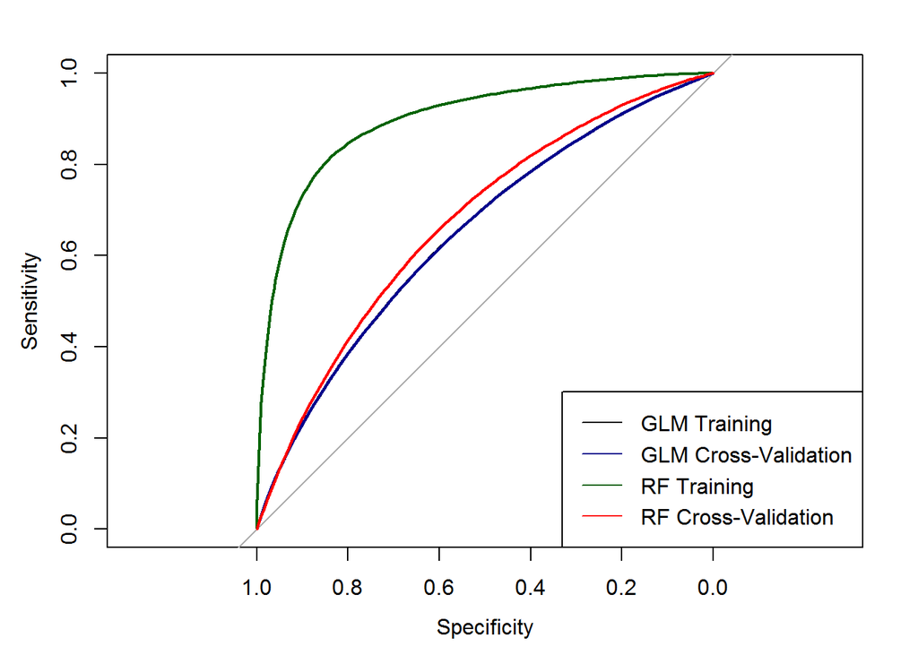

```r
legend("bottomright",  legend=c("GLM Training", "GLM Cross-Validation", "RF Training", "RF Cross-Validation"), col=c("black", "darkblue", "darkgreen", "red"), lwd=1)
```

- Create logistic regression and random forest predictive models using the “best” variables according to each method.

```r
best.glm <- pvalues[pvalues<1E-10]
names(best.glm)
```

```
## [1] "TV_HRS"           "DRIVE_HRS"        "ALCOHOL_INTAKE_C"
## [4] "SLEEP_C"          "CHRONO_C"
```

```r
best.rf <- imp[, 4][imp[, 4]>10]
names(best.rf)
```

```
## [1] "TV_HRS"                   "COMP_HRS"
## [3] "DRIVE_HRS"                "PHYSICAL_ACTIVITY_C"
## [5] "FRUITVEG_RECOMMEND_MET_C" "ALCOHOL_INTAKE_C"
## [7] "SLEEP_C"                  "CHRONO_C"
## [9] "BODY_FAT_N"
```